# Model 8 filtering results

```r
library(foreach)
library(iterators)
library(plyr)
library(tidyr)
library(dplyr)
library(ggplot2)
library(ggpubr)
library(doParallel)
registerDoParallel(cores= 6)
library(doRNG)
registerDoRNG(625904618)
library(pomp)
```

In this notebook I examine Model 8, which is SIRS with a seasonal birth pulse and we fit a seasonal drive for recovery rate.

We are not fitting population dynamics parameters except for the birth pulse. The params we are not fitting are at Aarons posterior estimates, and kappa = 5000 as fro the Clunes site estimates of bats are aroud 4000-6000. For the other params, we start the fitting with intiial values given by 5 repeats of Aaron’s posterior values and 25 point from a Sobol grid of his 95% CI"

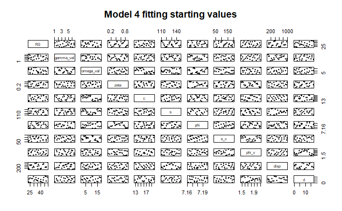

```r
pairs(~R0+gamma_val+omega_val+zeta+c+s+phi+s_v+phi_v+disp+d, data = guesses, pch = 20, main = "Model 4 fitting starting values")
```

```
Using 2000 particels and 50 iterations with iterated filtering, we got the following results for iterated filtering:
```

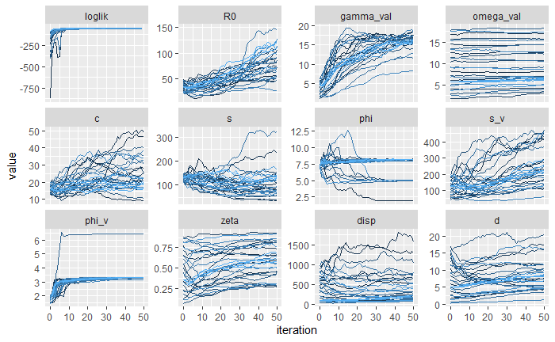

```r
mf3iter2 %>%
  traces() %>%
  melt() %>%
  filter(variable %in% c("loglik", "R0", "omega_val", "gamma_val",  "zeta", "c",
                         "s", "phi","s_v", "phi_v", "disp", "d") )%>%
  ggplot(aes(x=iteration,y=value,group=L1,color=L1))+
  geom_line()+
  facet_wrap(~variable,scales="free_y")+
  guides(color=FALSE) -> pl1

plot(pl1)
```

Here we see that the loglikelihood went up quickly after the first few iterations, and then stayed at around the same level.

The param that converged for almost all initial guesses is phi_v (the seasonal drive shift), R0, s and gamma stayed in a smaller range. Some params, like omega and zeta didn’t move much from the initial guesses. Phi shows a set of well-defined local minima valleys that the values converge to.

The top values are the following, the best has loglik around -54, lower than what we found for the SILI model. We can also see that we have a large range for the end parameters.

```r
head(model8_likelihoods, 5) %>%
  select (c("loglik", "loglik.se", "R0", "gamma_val", "omega_val",  "zeta", "c",
                         "s", "phi","s_v", "phi_v", "disp", "d"))
```

|  | loglik | loglik.se | R0 | gamma_val | omega_val | zeta | c | s | phi | s_v | phi_v | disp | d |
| --- | --- | --- | --- | --- | --- | --- | --- | --- | --- | --- | --- | --- | --- |
| 1 | -54.69133 | 0.003293566 | 27.43327 | 8.337337 | 12.736979 | 0.8599598 | 38.14472 | 76.83291 | 7.955618 | 60.87919 | 3.170674 | 91.05990 | 1.234437 |
| 2 | -64.81067 | 0.016228433 | 70.30774 | 11.652822 | 6.556869 | 0.8148051 | 22.22618 | 146.76157 | 4.903600 | 136.54841 | 3.262018 | 171.14598 | 3.507119 |
| 3 | -66.34514 | 0.008055990 | 51.73001 | 12.880679 | 15.513969 | 0.5036671 | 32.74618 | 70.25272 | 8.142495 | 262.92443 | 3.282400 | 81.20734 | 4.655548 |
| 4 | -66.63718 | 0.023953355 | 84.03691 | 16.180780 | 4.271222 | 0.4654606 | 9.14081 | 34.16430 | 8.282611 | 161.52944 | 3.311500 | 106.27607 | 11.583319 |
| 5 | -66.91993 | 0.012651977 | 126.73970 | 15.794215 | 5.118962 | 0.3067222 | 17.02476 | 141.10152 | 5.091864 | 178.59692 | 3.324265 | 88.47741 | 16.315035 |

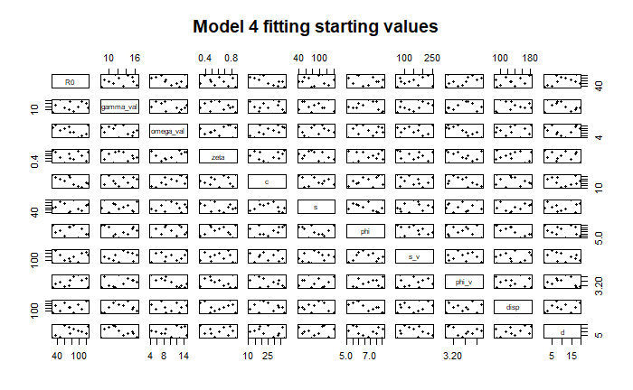

```r
pairs(~R0+gamma_val+omega_val+zeta+c+s+phi+s_v+phi_v+disp+d, data = guesses, pch = 20, main = "Model 4 fitting starting values")
```

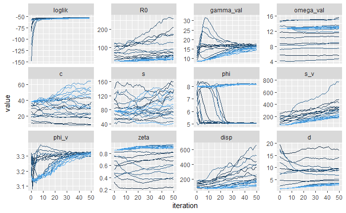

```r
mf3iter2 %>%
  traces() %>%
  melt() %>%
  filter(variable %in% c("loglik", "R0", "omega_val", "gamma_val",  "zeta", "c",
                         "s", "phi","s_v", "phi_v", "disp", "d") )%>%
  ggplot(aes(x=iteration,y=value,group=L1,color=L1))+
  geom_line()+
  facet_wrap(~variable,scales="free_y")+
  guides(color=FALSE) -> pl1

plot(pl1)
```

This is not a significantly better behavior and we didn’t get lower likelihoods , so I don’t think more particles improved the fitting process.

```r
head(model8_likelihoods_top_again, 5) %>%
  select (c("loglik", "loglik.se", "R0", "gamma_val", "omega_val",  "zeta", "c",
                         "s", "phi","s_v", "phi_v", "disp", "d"))
```

|  | loglik | loglik.se | R0 | gamma_val | omega_val | zeta | c | s | phi | s_v | phi_v | disp | d |
| --- | --- | --- | --- | --- | --- | --- | --- | --- | --- | --- | --- | --- | --- |
| 1 | -67.06955 | 0.009424884 | 33.86312 | 14.30434 | 12.84126 | 0.9310152 | 55.58347 | 111.65694 | 8.154702 | 185.3408 | 3.305171 | 100.2185 | 2.755637 |
| 2 | -68.63333 | 0.011231534 | 35.36645 | 15.38606 | 12.83445 | 0.8856554 | 51.31158 | 86.70271 | 8.192739 | 195.9029 | 3.316204 | 119.9512 | 3.207577 |
| 3 | -69.69170 | 0.005857619 | 38.11268 | 15.43650 | 13.23090 | 0.9051218 | 30.53510 | 41.06836 | 8.204382 | 216.2097 | 3.318659 | 115.2379 | 3.227558 |
| 4 | -69.75009 | 0.004167350 | 47.59756 | 14.95546 | 13.06283 | 0.9020753 | 43.06090 | 94.80421 | 8.173538 | 243.6904 | 3.312795 | 129.0979 | 3.173122 |
| 5 | -71.32270 | 0.013208642 | 35.64575 | 16.01387 | 13.22371 | 0.9122645 | 64.26669 | 139.59927 | 8.189958 | 201.8716 | 3.319295 | 164.8939 | 3.292631 |

Let us combine them to have all results in the same place.

```r
model8_likelihoods %>%
bind_rows(model8_likelihoods_top_again) %>%
arrange(-loglik) %>% write.csv("model8_likelihoods.csv")
getwd()
```

```
[1] "C:/Users/alexa/OneDrive/Documents/BatsProject/Australian model/pics_and_results/model_8_if"
```

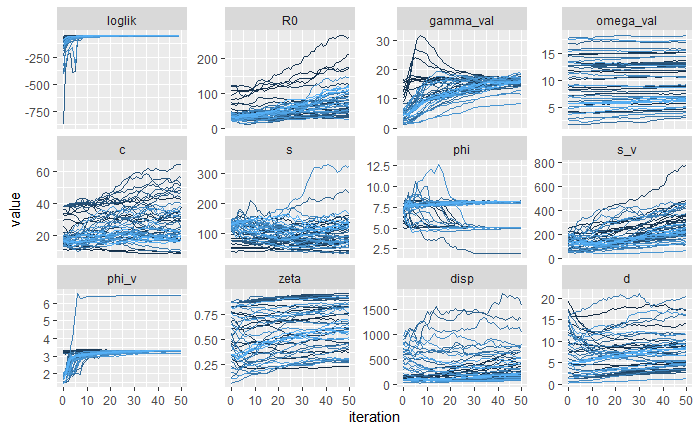

```r
append(mf3iter2, first_mf3iter2) %>%
  traces() %>%
  melt() %>%
  filter(variable %in% c("loglik", "R0", "omega_val", "gamma_val",  "zeta", "c",
                         "s", "phi","s_v", "phi_v", "disp", "d") )%>%
  ggplot(aes(x=iteration,y=value,group=L1,color=L1))+
  geom_line()+
  facet_wrap(~variable,scales="free_y")+
  guides(color=FALSE) -> pl1

plot(pl1)
```

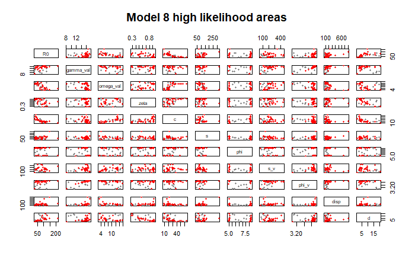

```r
  all <- ldply(list(guess=guesses,result=subset(model8_likelihoods,loglik>max(loglik)-20)))
pairs(~R0+gamma_val+omega_val+zeta+
        c+s+phi+s_v+phi_v+disp+d,data=all,col=ifelse(all$.id=="guess",grey(0.5),"red"),pch=20,main ="Model 8 high likelihood areas" )
```

On this plot, we look independently at the likelihoods of the resulting parameter values:

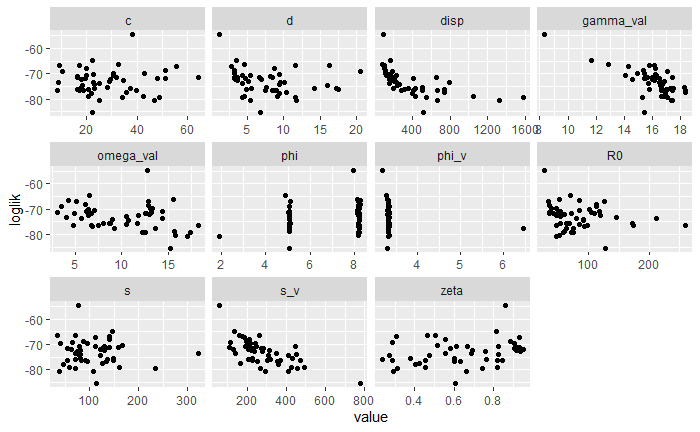

```r
gather(model8_likelihoods, key, value, -loglik) %>%
  filter(key %in% c( "R0", "gamma_val", "omega_val",  "zeta", "c",
                              "s", "phi","s_v", "phi_v", "disp", "d")) %>%
ggplot(aes(value, loglik), main = "Results of model 8 IF") +
   geom_point() +
  facet_wrap(~ key , scales="free_x", ncol=4) -> pl4

plot(pl4)
```

```
Now we take the best four results and simulate with them, to see what we got:
```

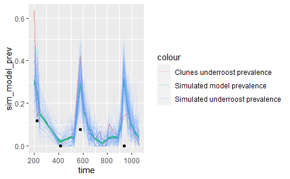

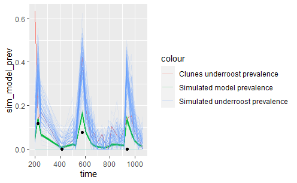

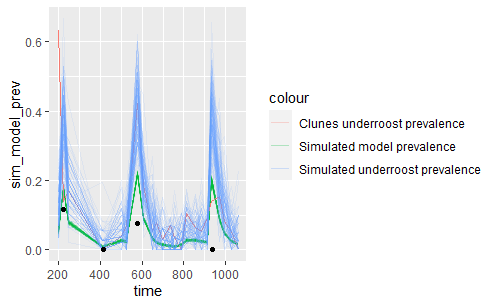

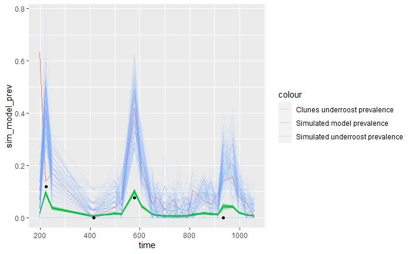